# 1. Introduction

3 gennaio 2023

#### Package

MMRFVariant 2.0.0

# 1 MMRFVariant Use-Case

For a more intuitive interpretation of the results, MMRFVariant provides a graphical or tabular representation of the outputs. The use-case diagram shown below provides an overview of the MMRFVariant functionalities and the different scenarios that can be performed.

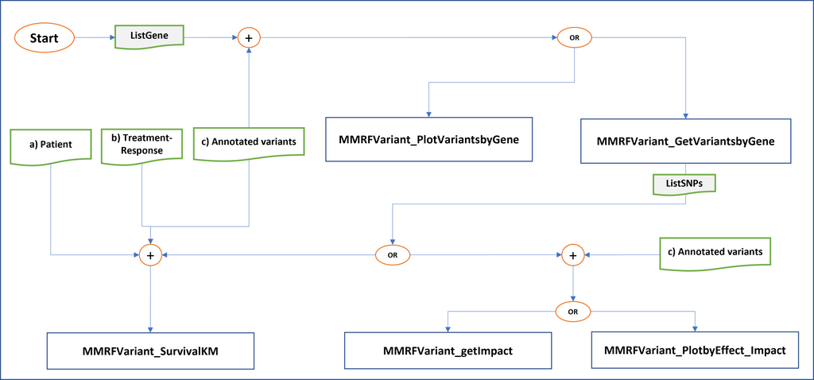

Figure 1: Use-case diagram that represents the high-level functionalities of MMRFVariant

# 2 Required libraries

```r
library(MMRFVariant)
library(dplyr)
library(DT)
library(ggplot2)
library(stringr)
library(ggpubr)
library(survminer)
library(survival)
library(formattable)
```

# 3 Download and Install

To install this package, start R (version “4.0.0”) and enter:

```r
devtools::install_github("marziasettino/MMRFVariant", build_vignettes = TRUE)
library(MMRFVariant)
```

# 4 **MMRFVariant Functions**

The following Figure shows the MMRFVariant functions and their input/outp. The first two columns show respectively the category (Column ”Cat.”) to which the function belongs and the name of the function. The two latter columns show the input and output of the functions. If the input is labelled with ∗ the input is not mandatory. The labels (a),(b),(c) at the column ”Input” refer to the datasets described in the following Section MMRFVariant Datasets

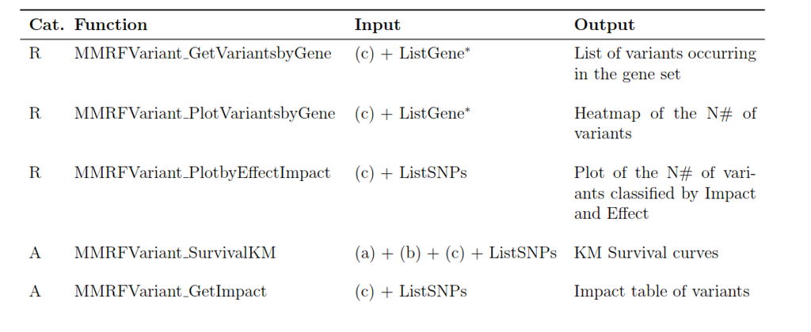

Figure 2: MMRFVariant Functions

# 5 MMRFVariant Datasets

MMRF-CoMMpass data can be retrieved directly from [MMRF-Commpass Researcher Gateway](https://research.themmrf.org/). They can be downloaded and imported as a dataframe into R environment.

MMRFVariant deals with the IA15 dataset (GRCh37 reference genome), which represents the ﬁfteen release of the complete baseline, available in a ﬂat ﬁle format (i.e. csv/txt) at the MMRF-RG.

With regard to the structure of IA15, it incorporates the following datasets:

**MMRFVariant Datasets**

- **MMRF_CoMMpass_IA15_PER_PATIENT**: contains patient-clinical data such as demographic (e.g. age, gender, race, ethnicity) and cytogenetics (e.g. FISH results) information beside of the ISS disease stage for each patient;
- **MMRF_CoMMpass_IA15_STAND_ALONE_TRTRESP**: contains the treatment-response information for each patient;
- **MMRF_CoMMpass_IA15a_All_Canonical_Variants**: contains the variants annotations including the impact and eﬀect beside of the SIFT and Polyphen2 scores and the dbSNP Identiﬁers (IDs).

## 5.1 Fetching and importing MMRF-COMMPASS datasets

MMRFVariant requires a local copy of the MMRFCoMMpass datasets that can be downloaded from the MMRF-RG by the registered users. Once the datasets have been downloaded, they can be saved locally in a tab-delimited text ﬁle format for importing them into the R environment as described below.

```r
patient <- read.csv("~/MMRF_CoMMpass_IA15_PER_PATIENT")

trt <- read.csv("~/MMRF_CoMMpass_IA15_STAND_ALONE_TRTRESP")

variant.ann <- read.csv("~/MMRF_CoMMpass_IA15a_All_Canonical_Variants")
```

# 6 Testing MMRFVariant functions

In order to test the MMRFVariant functions (without fetch MMRF-CoMMpass data from MMRF-RG), three fictitious datasets are provided in the “data” directory:

- <variant.ann.example>
- <patient.example>
- <trt.example>

They replicate the original datasets format including only some fileds with respect to MMRF-CoMMpass datasets (.csv files) downloaded from MMRF-COMMPASS Research Gateway.

**Annotated variant dataframe**

```r
datatable(variant.ann.example,options = list(scrollX = TRUE, keys = TRUE))
```

|  | Sample | X.CHROM | POS | ID | REF | ALT | X1000G | COSMIC_C | COSMIC_NC | EXAC | DB | NHLBI | CALLERS_COUNT | SEURAT | MUTECT | STRELKA | RNA_REF_COUNT | RNA_ALT_COUNT | RNA_ALT_FREQ | GEN.0..AD.0. | GEN.0..AD.1. | GEN.0..AR | GEN.0..DP | GEN.1..AD.0. | GEN.1..AD.1. | GEN.1..AR | GEN.1..DP | dbNSFP_GERP___RS | dbNSFP_LRT_score | … |
| --- | --- | --- | --- | --- | --- | --- | --- | --- | --- | --- | --- | --- | --- | --- | --- | --- | --- | --- | --- | --- | --- | --- | --- | --- | --- | --- | --- | --- | --- | --- |
| 1 | MMRF_0001 | 1 | 607 | rs445669843 | C | T | . | . | . | true | true | . | 2 | . | true | true | . | . | . | 46 | 0 | 0 | 46 | 29 | 5 | 0.147 | 34 | 3.23 | 0.000136 | … |
| 2 | MMRF_0002 | 1 | 605 | rs123588843 | G | GGCCT | true | . | . | . | true | . | 2 | true | . | true | . | . | . | 22 | 0 | 0 | 45 | 9 | 9 | 0.5 | 33 | . | . | … |
| 3 | MMRF_0003 | 3 | 602 | rs75551234 | A | C | . | . | . | . | . | . | 2 | . | true | true | . | . | . | 72 | 0 | 0 | 73 | 19 | 13 | 0.406 | 32 | . | . | … |
| 4 | MMRF_0004 | 1 | 606 | rs678448843 | A | C | . | . | . | . | . | . | 2 | . | true | true | . | . | . | 72 | 0 | 0 | 73 | 19 | 13 | 0.406 | 32 | . | . | … |
| 5 | MMRF_0005 | 3 | 607 | rs69582243 | A | G | . | . | . | . | . | . | 3 | true | true | true | . | . | . | 86 | 0 | 0 | 86 | 23 | 26 | 0.531 | 49 | 5.84 | 0.540752 | … |
| 6 | MMRF_0006 | 2 | 601 | rs75566841 | C | T | . | . | . | . | . | . | 3 | true | true | true | . | . | . | 287 | 0 | 0 | 287 | 161 | 48 | 0.23 | 209 | . | . | … |
| 7 | MMRF_0007 | 3 | 605 | rs755588843 | G | A | . | . | . | . | . | . | 3 | true | true | true | . | . | . | 79 | 0 | 0 | 79 | 78 | 9 | 0.103 | 87 | . | . | … |
| 8 | MMRF_0008 | 3 | 610 | rs752288843 | G | A | . | . | . | . | . | . | 3 | true | true | true | . | . | . | 130 | 1 | 0.008 | 131 | 127 | 25 | 0.164 | 152 | . | . | … |
| 9 | MMRF_0009 | 2 | 603 | rs755588843 | G | A | . | . | . | . | . | . | 3 | true | true | true | . | . | . | 130 | 1 | 0.008 | 131 | 127 | 25 | 0.164 | 152 | . | . | … |
| 10 | MMRF_0010 | 2 | 609 | rs755521843 | C | G | . | . | . | . | . | . | 3 | true | true | true | . | . | . | 214 | 0 | 0 | 214 | 270 | 29 | 0.097 | 299 | 2.52 | . | … |

**Patient dataframe**

```r
datatable(patient.example,options = list(scrollX = TRUE, keys = TRUE))
```

|  | public_id | D_PT_PRIMARYREASON | D_PT_deathdy | D_PT_lstalive | DEMOG_GENDER | DEMOG_ETHNICITY | D_PT_issstage_char |
| --- | --- | --- | --- | --- | --- | --- | --- |
| 1 | MMRF_0001 | Death |  | 250 | 1 | Hispanic or Latino | Stage III |
| 2 | MMRF_0002 |  |  | 356 | 1 | Hispanic or Latino | Stage III |
| 3 | MMRF_0003 |  | 2226 |  | 1 | Hispanic or Latino | Stage III |
| 4 | MMRF_0004 | Death | 172 |  | 1 | Hispanic or Latino | Stage II |
| 5 | MMRF_0005 | Death |  | 1814 | 1 | Hispanic or Latino | Stage II |
| 6 | MMRF_0006 | Death |  | 223 | 2 | Not Hispanic or Latino | Stage I |
| 7 | MMRF_0007 | NA | 1328 |  | 2 | Not Hispanic or Latino | Stage I |
| 8 | MMRF_0008 | NA | 681 |  | 2 | Not Hispanic or Latino | Stage I |
| 9 | MMRF_0009 | Death | 786 |  | 2 | Not Hispanic or Latino | Stage I |
| 10 | MMRF_0010 | Death |  | 1450 | 2 | Not Hispanic or Latino | Stage I |

**Treatment dataframe**

```r
datatable(trt.example,options = list(scrollX = TRUE, keys = TRUE))
```

|  | public_id | trtclass | bestresp |
| --- | --- | --- | --- |
| 1 | MMRF_0001 | Bortezomib-based | Partial Responsed |
| 2 | MMRF_0002 | Bortezomib-based | Partial Responsed |
| 3 | MMRF_0003 | IMIDs-based | Partial Responsed |
| 4 | MMRF_0004 | IMIDs-based | Partial Responsed |
| 5 | MMRF_0005 | IMIDs-based | Partial Responsed |
| 6 | MMRF_0006 | IMIDs-based | Very Good Partial Response |
| 7 | MMRF_0007 | IMIDs-based | Very Good Partial Response |
| 8 | MMRF_0008 | combined bortezomib/IMIDs-based | Very Good Partial Response |
| 9 | MMRF_0009 | combined bortezomib/IMIDs-based | Very Good Partial Response |
| 10 | MMRF_0010 | combined bortezomib/IMIDs-based | Very Good Partial Response |

# 7 Question and issues

Please use [Github issues](https://github.com/marziasettino/MMRFVariant/issues) if you want to file bug reports or feature requests.